# Graduate Earnings Over Time

WARREN LANGRIDGE

```r
library(tidyverse)
```

## Introduction

```r
load("../gradMS.Rdata")

gradMS <- gradMS %>%
  filter(Gender != "Other gender")

gradMS_wider <- gradMS |>
  pivot_wider(names_from = Statistic, values_from = .)

gradMS_wider_lighter <- na.omit(gradMS_wider)

gradMS_pearnings <- gradMS_wider_lighter %>% pivot_longer(cols = starts_with("P"),
                                                names_to = "pearn",
                                                values_to = "earnings")
```

## Including Plots

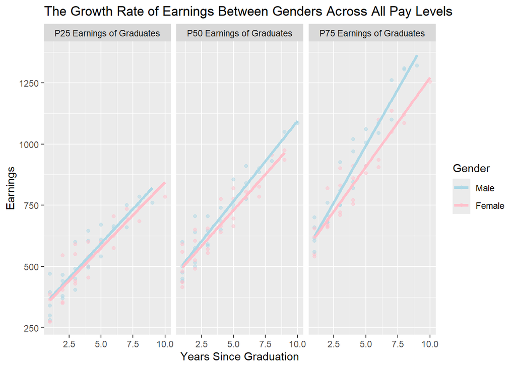

```r
gradMS_pearnings %>% filter(Gender == c("Male", "Female")) %>%
  ggplot(aes(x = Years.Since.Graduation,
             y = earnings,
             colour = Gender)) +
  geom_point(alpha = 0.5) +
  scale_colour_manual(values = c("lightblue","pink")) +
  geom_smooth(se =F, method = "lm",
              alpha = 1,
              size = 1.3) +
  facet_wrap(vars(pearn)) +
  labs(title = "The Growth Rate of Earnings Between Genders Across All Pay Levels",
       x = "Years Since Graduation",
       y = "Earnings")
```

This graph illustrates the growth rate of earnings between male and female graduates across the 25th, 50th, and 75th percentiles over a ten-year period post-graduation. I created this visualization to analyse the question, is the growth rate of earnings the same for university graduates of differing genders? What we see is a consistent pattern: male graduates tend to experience steeper income growth than their female counterparts, regardless of whether they start in the lower, middle, or upper end of the earnings distribution. At every level, 0 years after graduation, Males and Females seem to have the same earnings, as time progresses Males earn more

For the P25 Level the growth rate is faster for males but relatively not by much

For the P50 level the growth rate is steeper than the P25 level

For the P75 level the growth rate is much steeper than the other P-levels, and every year after 2.5 years we can see a gap between the genders.

So we can see not only are males earning more, their earnings are growing faster at every pay level